# The Curious Case of a Scale Parameter

Jyotishka Datta

July 9, 2017

## A Toy Example

We consider a 2-dimensional linear regression $Y = X \beta + \epsilon$ where $\beta = (20,20)$ and $X$ is an identity matrix.

```r
set.seed(123)

X = matrix(rep(c(1, 0, 0, 1), 1),
           ncol=2,
           byrow=T)

beta = c(20, 20)

y_hat = X %*% beta

(y = drop(y_hat + rnorm(nrow(X))))
```

```
## [1] 19.43952 19.76982
```

We will use two different methods: horseshoe using the `horseshoe` R package and a Bayesian version of scaled / square-root Lasso.

### Horseshoe results

```r
library(horseshoe)
res <- horseshoe(y, X, method.tau = "halfCauchy",
                 method.sigma = "Jeffreys",
                 burn = 1000, nmc = 5000, alpha = 0.05)
```

```
## [1] 1000
## [1] 2000
## [1] 3000
## [1] 4000
## [1] 5000
## [1] 6000
```

```r
(postmean_HS <- res$BetaHat)
```

```
## [1] 7.367877 7.684735
```

```r
(postmedian_HS <- res$BetaMedian)
```

```
## [1] 3.838521 4.184498
```

The posterior mean and median estimates are shrunk away from the true mean value, 20. The posterior mode is even more wrong.

```r
Mode <- function(x) {
  ux <- unique(x)
  ux[which.max(tabulate(match(x, ux)))]
}
(map_HS <- apply(res$BetaSamples,1,Mode))
```

```
## [1] -26.71354  17.33860
```

```r
#'
#'  Version of HS sampler with relative tau scaling.
#'
horseshoe_rel <- function(y, X,
                          method.tau = c("relative", "fixed", "truncatedCauchy", "halfCauchy"),
                          tau = 1,
                          method.sigma = c("fixed", "Jeffreys"),
                          Sigma2 = 1,
                          burn = 1000, nmc = 5000, thin = 1, alpha = 0.05)
{
    method.tau = match.arg(method.tau)
    method.sigma = match.arg(method.sigma)
    ptm = proc.time()
    N = burn + nmc
    effsamp = (N - burn)/thin
    n = nrow(X)
    p = ncol(X)
    Beta = rep(0, p)
    lambda = rep(1, p)
    sigma_sq = Sigma2
    betaout = matrix(0, p, effsamp)
    tauout = rep(0, effsamp)
    sigmaSqout = rep(0, effsamp)
    if (p > n)
        algo = 1
    else algo = 2
    I_n = diag(n)
    l0 = rep(0, p)
    l1 = rep(1, n)
    l2 = rep(1, p)
    if (algo == 2) {
        Q_star = t(X) %*% X
    }
    for (i in 1:N) {
        if (algo == 1) {
            lambda_star = tau * lambda
            U = as.numeric(lambda_star^2) * t(X)
            u = stats::rnorm(l2, l0, lambda_star)
            v = X %*% u + stats::rnorm(n)
            v_star = solve((X %*% U + I_n), ((y/sqrt(sigma_sq)) -
                v))
            Beta = sqrt(sigma_sq) * (u + U %*% v_star)
        }
        else if (algo == 2) {
            lambda_star = tau * lambda
            L = chol((1/sigma_sq) * (Q_star + diag(1/as.numeric(lambda_star^2),
                p, p)))
            v = solve(t(L), t(t(y) %*% X)/sigma_sq)
            mu = solve(L, v)
            u = solve(L, stats::rnorm(p))
            Beta = mu + u
        }
        eta = 1/(lambda^2)
        upsi = stats::runif(p, 0, 1/(1 + eta))
        tempps = Beta^2/(2 * sigma_sq * tau^2)
        ub = (1 - upsi)/upsi
        Fub = 1 - exp(-tempps * ub)
        Fub[Fub < (1e-04)] = 1e-04
        up = stats::runif(p, 0, Fub)
        eta = -log(1 - up)/tempps
        lambda = 1/sqrt(eta)
        if (method.tau == "halfCauchy" ||
            method.tau == "relative") {
            tempt = sum((Beta/lambda)^2)/(2 * sigma_sq)
            et = 1/tau^2
            utau = stats::runif(1, 0, 1/(1 + et))
            ubt = (1 - utau)/utau
            Fubt = stats::pgamma(ubt, (p + 1)/2, scale = 1/tempt)
            Fubt = max(Fubt, 1e-08)
            ut = stats::runif(1, 0, Fubt)
            et = stats::qgamma(ut, (p + 1)/2, scale = 1/tempt)
            if (method.tau == "relative") {
              tau = sqrt(sigma_sq/et)
            } else {
              tau = sqrt(1/et)
            }
        }
        if (method.tau == "truncatedCauchy") {
            tempt = sum((Beta/lambda)^2)/(2 * sigma_sq)
            et = 1/tau^2
            utau = stats::runif(1, 0, 1/(1 + et))
            ubt_1 = 1
            ubt_2 = min((1 - utau)/utau, p^2)
            Fubt_1 = stats::pgamma(ubt_1, (p + 1)/2, scale = 1/tempt)
            Fubt_2 = stats::pgamma(ubt_2, (p + 1)/2, scale = 1/tempt)
            ut = stats::runif(1, Fubt_1, Fubt_2)
            et = stats::qgamma(ut, (p + 1)/2, scale = 1/tempt)
            tau = 1/sqrt(et)
        }
        if (method.sigma == "Jeffreys") {
            if (algo == 1) {
                E_1 = max(t(y - X %*% Beta) %*% (y - X %*% Beta),
                  (1e-10))
                E_2 = max(sum(Beta^2/((tau * lambda))^2), (1e-10))
            }
            else {
                E_1 = max(t(y - X %*% Beta) %*% (y - X %*% Beta),
                  1e-08)
                E_2 = max(sum(Beta^2/((tau * lambda))^2), 1e-08)
            }
            sigma_sq = 1/stats::rgamma(1, (n + p)/2, scale = 2/(E_1 +
                E_2))
        }
        if (i%%1000 == 0) {
            print(i)
        }
        if (i > burn && i%%thin == 0) {
            betaout[, (i - burn)/thin] = Beta
            tauout[(i - burn)/thin] = tau
            sigmaSqout[(i - burn)/thin] = sigma_sq
        }
    }
    pMean = apply(betaout, 1, mean)
    pMedian = apply(betaout, 1, stats::median)
    pSigma = mean(sigmaSqout)
    pTau = mean(tauout)
    left <- floor(alpha * effsamp/2)
    right <- ceiling((1 - alpha/2) * effsamp)
    BetaSort <- apply(betaout, 1, sort, decreasing = F)
    left.points <- BetaSort[left, ]
    right.points <- BetaSort[right, ]
    result = list(BetaHat = pMean, LeftCI = left.points, RightCI = right.points,
        BetaMedian = pMedian, Sigma2Hat = pSigma, TauHat = pTau,
        BetaSamples = betaout, TauSamples = tauout, Sigma2Samples = sigmaSqout)
    return(result)
}
```

This is unexpected given the tail-robustness property of horseshoe prior. The contour plot also shows that the density is concentrated around zero.

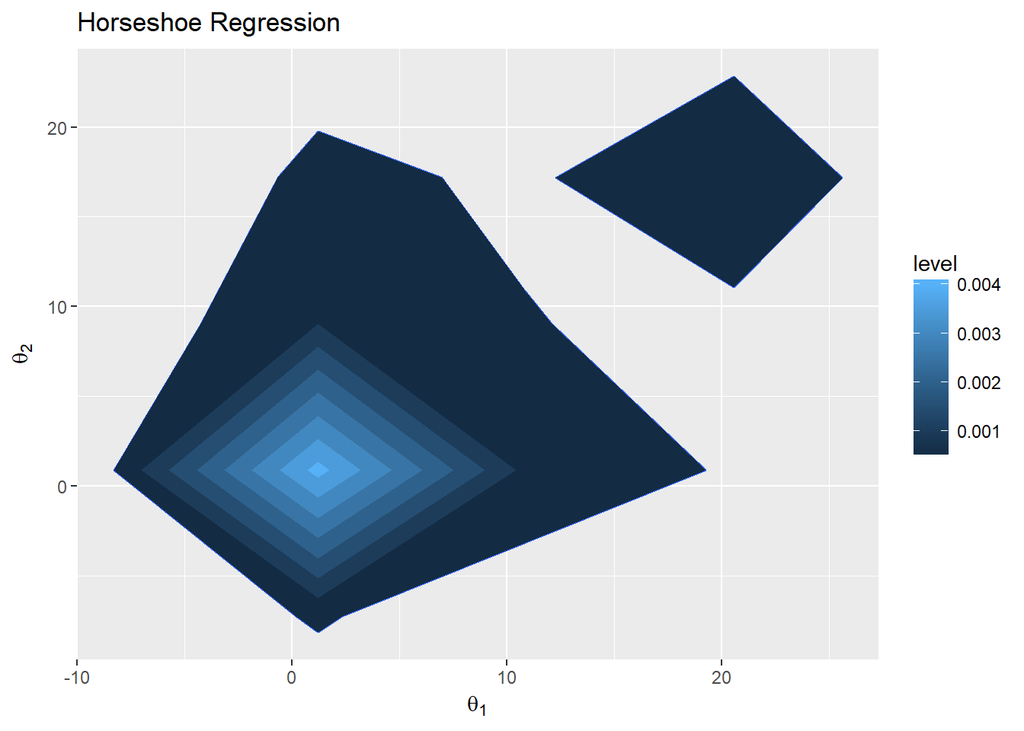

```r
library(ggplot2)

theta.smpls.hs <- t(res$BetaSamples)
colnames(theta.smpls.hs) = c("theta1", "theta2")

hs.2d.density<- ggplot(as.data.frame(theta.smpls.hs), aes(theta1, theta2)) +
  geom_density2d() + stat_density2d(aes(fill = ..level..), geom="polygon") +
  xlab(expression(theta[1])) + ylab(expression(theta[2])) + ggtitle("Horseshoe Regression")

print(hs.2d.density)
```

Next, we produce samples under $\tau \sim C^{+}(0, \sigma)$.

```r
res_rel <- horseshoe_rel(y, X, method.tau = "relative",
                 method.sigma = "Jeffreys",
                 burn = 1000, nmc = 5000, alpha = 0.05)
```

```
## [1] 1000
## [1] 2000
## [1] 3000
## [1] 4000
## [1] 5000
## [1] 6000
```

We can also produce a marginal view of the two $\theta$ values.

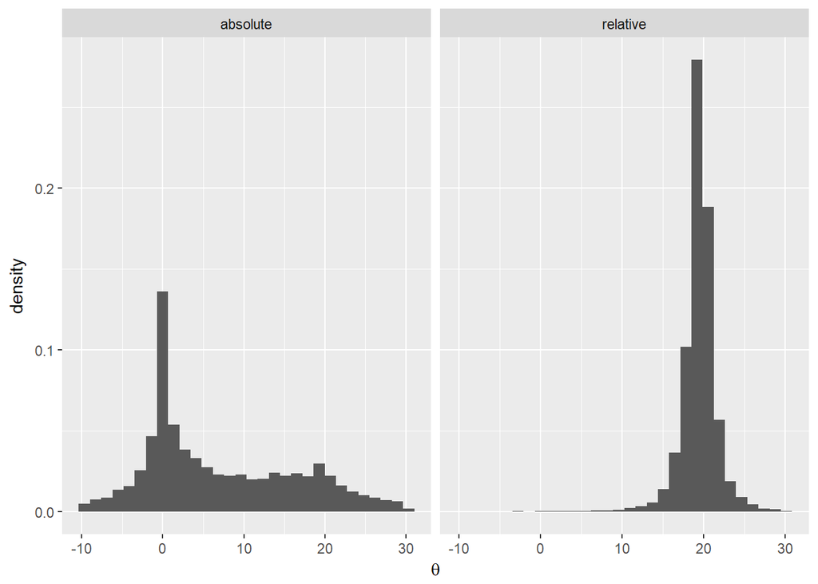

```r
library(reshape2)
library(dplyr)

theta_smpls_abs_hs_melt = melt(res$BetaSamples)
theta_smpls_abs_hs_melt = theta_smpls_abs_hs_melt %>% filter(value > -10 & value < 30)
theta_smpls_abs_hs_melt$tau_prior = "absolute"

theta_smpls_rel_hs_melt = melt(t(res_rel$BetaSamples))
theta_smpls_rel_hs_melt = theta_smpls_rel_hs_melt %>% filter(value > -10 & value < 30)
theta_smpls_rel_hs_melt$tau_prior = "relative"

theta_smpls_hs_melt = rbind(theta_smpls_abs_hs_melt, theta_smpls_rel_hs_melt)

ggplot(theta_smpls_hs_melt, aes(value, ..density..)) +
  geom_histogram() +
  facet_grid(. ~ tau_prior, scales='free') + xlab(expression(theta))
```

```r
  # ggtitle("Absolute scaling") + xlab(expression(theta))
```

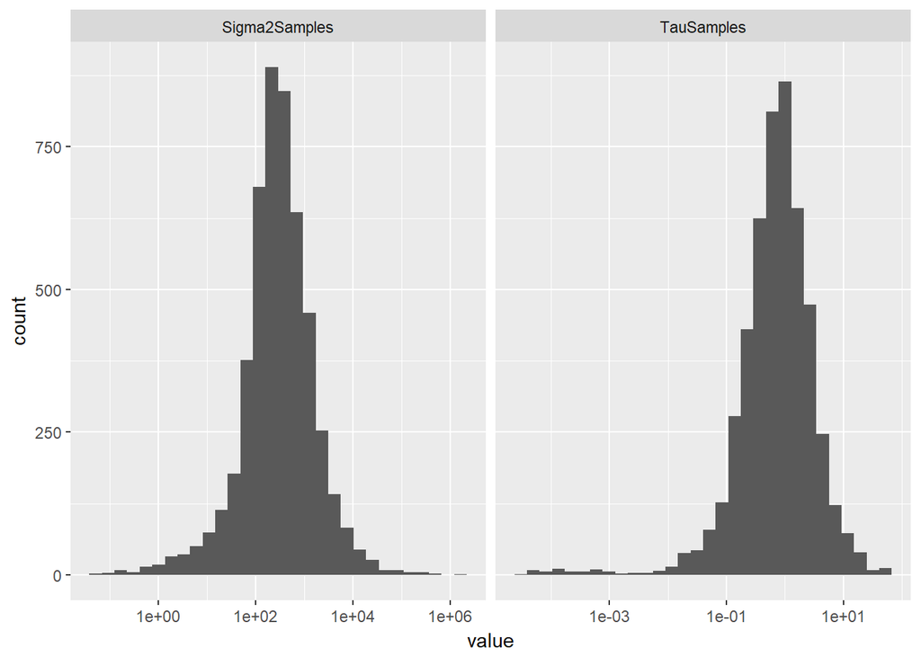

```r
library(reshape2)

sigma2_tau_df = as.data.frame(res[c("Sigma2Samples", "TauSamples")])
sigma2_tau_df = melt(sigma2_tau_df)

variance_hists = ggplot(sigma2_tau_df, aes(value)) +
  facet_grid(. ~ variable, scales='free') +
  geom_histogram()
variance_hists = variance_hists + scale_x_log10()
print(variance_hists)
```

### Bayesian Square Root Lasso Results

```r
source("bayes.sqrt.lasso.R")
res2 <- bayes.sqrt.lasso(Y = y,method.tau ="gamma", r = 1, delta = 2, burn = 1000, nmc = 5000, verbose=FALSE)

(postmean_SQL <- res2$ThetaHat)
```

```
## [1] 19.34687 19.68302
```

The mode is close to the true value:

```r
(map_SQL <- apply(res2$ThetaSave,2,Mode))
```

```
## [1] 18.53720 21.46716
```

Now, the contour plot:

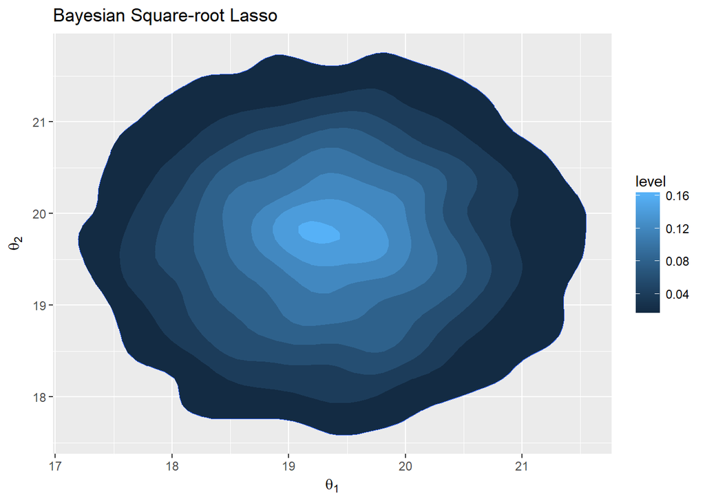

```r
theta.smpls.sql <- res2$ThetaSave
colnames(theta.smpls.sql) = c("theta1", "theta2")


sql.2d.density<- ggplot(as.data.frame(theta.smpls.sql), aes(theta1, theta2)) +
  geom_density2d()+stat_density2d(aes(fill = ..level..), geom="polygon")+
  xlab(expression(theta[1]))+ylab(expression(theta[2]))+ggtitle("Bayesian Square-root Lasso")
print(sql.2d.density)
```

### Not $\tau$, but $\sigma$

The problem with horseshoe prior doesn’t go away if one uses a half-Cauchy (non-truncated) prior on $\tau$ or use the Empirical Bayes method.

```r
res <- horseshoe(y, X, method.tau = "fixed", method.sigma = "Jeffreys",
                 burn = 1000, nmc = 5000, alpha = 0.05)
```

```
## [1] 1000
## [1] 2000
## [1] 3000
## [1] 4000
## [1] 5000
## [1] 6000
```

```r
(postmean_HS <- res$BetaHat)
```

```
## [1] 8.551365 8.764789
```

```r
(postmedian_HS <- res$BetaMedian)
```

```
## [1] 6.658385 6.523543
```

```r
(map_HS <- apply(res$BetaSamples,1,Mode))
```

```
## [1]  2.874758 -1.325694
```

The $\sigma^2$ samples for Jeffrey’s prior:

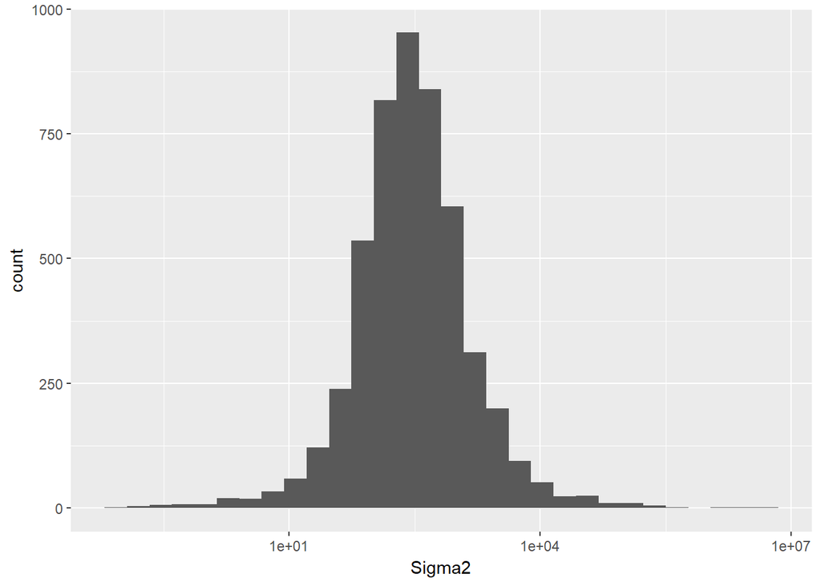

```r
ggplot(data.frame(Sigma2=res$Sigma2Samples), aes(Sigma2)) + geom_histogram() + scale_x_log10()
```

However, if we use the Empirical Bayes method for estimating $\sigma^2$ instead of using the Jeffrey’s prior on $\sigma^2$, the sitaution improves:

```r
res3 <- horseshoe(y, X, method.tau = "fixed", method.sigma = "fixed",
                  burn = 1000, nmc = 5000, alpha = 0.05)
```

```
## [1] 1000
## [1] 2000
## [1] 3000
## [1] 4000
## [1] 5000
## [1] 6000
```

```r
(postmean_HS <- res3$BetaHat)
```

```
## [1] 19.33687 19.67706
```

```r
(postmedian_HS <- res3$BetaMedian)
```

```
## [1] 19.33693 19.69819
```

```r
(map_HS <- apply(res3$BetaSamples, 1, Mode))
```

```
## [1] 20.39255 18.63974
```

The contour plot looks correct now.

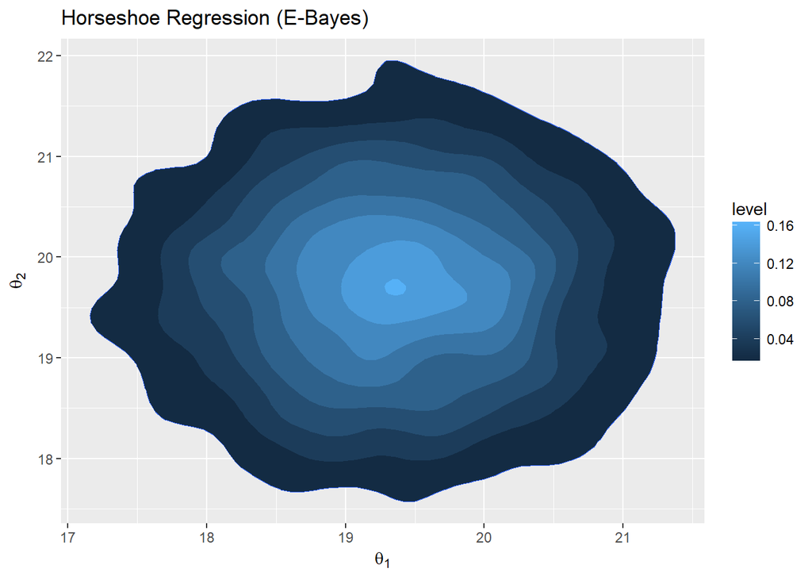

## Multivariate Normal Means Example

This situation prevails even when the underlying $\beta$ vector is a multivariate parameter with half of the values set to zero. (This is not a sparse situation as the proportion of non-null effects is exactly 0.5.)

```r
beta = c(rep(20,50),rep(0,50))
X = diag(100)
y_hat = X %*% beta
y = drop(y_hat + rnorm(nrow(X)))
```

We will use two different methods: horseshoe using the `horseshoe` R package and a Bayesian version of scaled / square-root Lasso.

### Horseshoe results

```r
library(horseshoe)
res <- horseshoe(y, X, method.tau = "fixed",
                 method.sigma = "Jeffreys",
                 burn = 1000, nmc = 5000, alpha = 0.05)
```

```
## [1] 1000
## [1] 2000
## [1] 3000
## [1] 4000
## [1] 5000
## [1] 6000
```

```r
(postmean_HS <- res$BetaHat)
```

```
##   [1] 11.043793713 11.218454407 11.023312995  9.214412473 10.782039576
##   [6] 11.205118422 11.159329600  9.964981503  8.917099227 13.434057396
##  [11] 10.021891132 10.101809116 11.776693512 10.584276645 10.363587588
##  [16] 13.245540327 12.513236719 11.590284196 11.323203047 10.660140304
##  [21] 10.099882234 12.128882698 10.811407985 10.910322478 12.142362359
##  [26]  9.449117745 10.952106008 12.155479937 10.524815224 10.871062968
##  [31] 11.970564042 11.690594516 10.479869022 10.255458272 10.523104204
##  [36]  8.876255148 10.590446768 12.489592618 11.106769547  9.768324412
##  [41] 10.541003984  9.692818389 10.281586971  9.844760354 13.487481150
##  [46] 11.259001282 13.012405877 10.931427057 11.064527466 10.481258848
##  [51] -0.382113592  0.029881074  0.038644836  0.225846562 -0.030298878
##  [56] -0.133721995 -0.348347385  0.204833792 -0.500179000 -0.088170770
##  [61] -0.328380436  0.075998643  0.046710469  0.281753702 -0.160291105
##  [66]  0.178406875 -0.432120786  0.189212127 -0.180608229 -0.443286362
##  [71] -0.023356871 -0.625332328  0.331653536 -0.296743809  0.181438053
##  [76]  0.055142485 -0.106732265 -0.256899402 -0.347276776 -0.137836739
##  [81] -0.195661748 -0.133598515  0.671017568  0.293682963  0.063674552
##  [86] -0.177452348 -0.100815115 -0.124466056 -0.525769100 -0.248235242
##  [91]  0.243877463 -0.210666329 -0.012712049 -0.254358918  0.186180550
##  [96]  0.100911378 -0.226832712  0.325176797 -0.827945709 -0.004619339
```

```r
(postmedian_HS <- res$BetaMedian)
```

```
##   [1]  9.8469626551 10.1404701016 10.0187750830  7.7996297849  9.7507090485
##   [6] 10.1700752799 10.2139983429  8.7953765917  7.1917756159 13.0123061376
##  [11]  8.6768623807  8.8347292037 11.1225118384  9.5619427331  9.0772544711
##  [16] 12.5768358341 11.7796709773 10.7513158286 10.2543603666  9.6131023797
##  [21]  9.0054705945 11.2582984675  9.7311289327  9.8570243841 11.6448914718
##  [26]  7.9859254492  9.9409472616 11.4441590866  9.3872552237  9.7059944029
##  [31] 11.1599958678 10.5650429314  9.3867524953  9.0790617062  9.2430900753
##  [36]  7.4600431922  9.3181665351 11.8928497450 10.1567686878  8.4200941996
##  [41]  9.3668783995  8.6528788118  9.2346991804  8.5573317914 12.9920667293
##  [46] 10.4312555290 12.3694699498  9.8433480805  9.9568609622  9.4323511760
##  [51] -0.0992213229  0.0113081139  0.0270038706  0.0394392082 -0.0105483322
##  [56] -0.0228398803 -0.0585925169  0.0316007293 -0.1314840452 -0.0125549959
##  [61] -0.0673775453  0.0189616675  0.0025733887  0.0859467579 -0.0402899479
##  [66]  0.0344155820 -0.0503247877  0.0430212388 -0.0135498820 -0.0759635791
##  [71]  0.0071558127 -0.1534901983  0.0645302800 -0.0436100804  0.0299381672
##  [76]  0.0221827241  0.0083782021 -0.0536997360 -0.0928174511 -0.0140607257
##  [81] -0.0505491582 -0.0265647654  0.1889866297  0.0390450901  0.0479331991
##  [86] -0.0310079123 -0.0024928855 -0.0335969021 -0.1933794338 -0.0091317075
##  [91]  0.0373384082 -0.0558469192  0.0003116284 -0.0171649865  0.0530879169
##  [96]  0.0002035802 -0.0603152687  0.0474537920 -0.2356242428  0.0044410538
```

```r
(map_HS <- apply(res$BetaSamples,1,Mode))
```

```
##   [1]  21.57658012  -0.97054069   6.38640937  13.70928061   9.90269984
##   [6]   9.15838996  16.68200825  14.51449607  14.40204177  17.62054408
##  [11]  -0.57412041   6.61644943   2.05126613   6.23049049  11.43808155
##  [16]   1.13447387   0.28103215  32.60505227   2.81136547  18.97849139
##  [21]   7.35878959  10.84489172   5.93430822  10.14278843  -2.03120955
##  [26]  34.06665539   7.16259003  13.05748309  19.99318665  17.98205684
##  [31]   2.32939821  39.26490215  16.31312025   7.24421062  24.52258363
##  [36]   3.11550232   3.61095380  21.60074719   6.60253523  36.05317965
##  [41]  29.46329795   2.22906919   6.04510497   6.02033481   7.40975259
##  [46]   0.66391569   0.31295938  13.55721025   5.74296233  -2.04884582
##  [51]   1.12228168   2.74010340  -7.11435331  -0.03681852  -2.90529187
##  [56]   5.30875522   1.90140559  -0.71442259  -4.15542438  -0.26912213
##  [61]  -0.37978343   0.62892020   1.79098605   0.12552131   0.29948968
##  [66]  -8.91611398   3.94991860  -9.62032596  -2.83084077   0.08000850
##  [71]   3.07268854 -17.25321677   3.72429509  -2.43352411   1.25831272
##  [76]  -0.89849410  -4.51881003  -0.11064168   8.47120900   1.99932983
##  [81]  -7.76728503   3.12272798  -0.43514177 -15.27764946 -12.81751581
##  [86]   4.31123368  -0.93428263  -2.62286103  -1.00190833  -4.49597848
##  [91]  -2.28147142  -5.85926437  -0.04802437   0.48853629  -0.48519784
##  [96]  -3.49199694   0.32639249   1.18845367  -3.40787099  -2.34896725
```

Bayesian Square-root Lasso is not affected.

```r
res2 <- bayes.sqrt.lasso(Y = y,method.tau ="gamma", r = 1, delta = 2, burn = 1000, nmc = 5000, verbose=FALSE)
(postmean_SQL <- res2$ThetaHat)
```

[output not shown]

Horseshoe prior can recover the true $\beta$ under the relatively scaled prior on the global shrinkage parameter $\tau \sim C^{+}(0, \sigma)$.

```r
res_rel <- horseshoe_rel(y, X, method.tau = "relative",
                 method.sigma = "Jeffreys",
                 burn = 1000, nmc = 5000, alpha = 0.05)
```

```
## [1] 1000
## [1] 2000
## [1] 3000
## [1] 4000
## [1] 5000
## [1] 6000
```

```r
(postmean_HS_rel <- res_rel$BetaHat)
```

```
##   [1] 20.01774642 20.52510954 19.89144838 18.21976166 20.17271505
##   [6] 20.04840415 20.58529349 18.63351054 18.78696580 22.26946647
##  [11] 19.64050316 19.79161900 20.18477664 19.73070476 19.73223638
##  [16] 22.24305348 21.46368981 20.20987574 20.45429117 19.79902658
##  [21] 19.17497149 20.69001323 20.06364887 19.70485666 20.64581527
##  [26] 18.63576830 20.38065598 21.07057545 19.29391041 20.04263124
##  [31] 20.77787063 20.99914742 19.40443258 19.67803480 19.64579419
##  [36] 17.77652377 20.21534148 20.93446477 19.80882700 18.92714787
##  [41] 19.43833026 18.44543860 18.85846702 19.11388644 22.46732427
##  [46] 20.00938882 22.40035923 19.96666065 19.58439166 19.06708554
##  [51] -0.55469752 -0.03033095  0.13721623  0.27040189 -0.02458232
##  [56] -0.29029482 -0.71471308  0.12257560 -0.96173085  0.28822596
##  [61] -0.56120335  0.09979209  0.19415260  0.42102143 -0.18663347
##  [66]  0.37873242 -0.88222881  0.17614505 -0.24869589 -0.43710582
##  [71] -0.03156794 -1.36415083  0.64474725 -0.81950940  0.22229764
##  [76]  0.07980484  0.06590269 -0.78239261 -0.53410458 -0.19307616
##  [81] -0.64949914 -0.18504571  1.42509103  0.66549968  0.07081795
##  [86] -0.35224929 -0.01751754 -0.27674487 -0.86404406 -0.33028445
##  [91]  0.54652989 -0.30698156 -0.05227910 -0.64681353  0.27036202
##  [96] -0.05997958 -0.48354094  0.37130433 -2.07323711 -0.04812811
```